# PK modelling, Machine Learning and the caret package

Carlos S Traynor

28/10/2019

## PD Response

In this presentation we are going to learn new Machine Learning algorithms, how to implement them in R and use them to make predictions in PD Response datasets. On the way we are going to learn how to generate data and check model predictions.

Sometimes we are looking whether we can predict the occurrence of an adverse event from variables, such as Dose, Weight, genotype. In this case it may be useful to use algorithms that can map variables to response and looking for patterns in the data and searching for hypothesis. Machine Learning has becoming increasingly popular a framework to make predictions using a ‘black-box’ model. In this workshop we are going to make an effort to see inside the black-box and understand its mechanism.

## The model

Let’s assume then the following model:

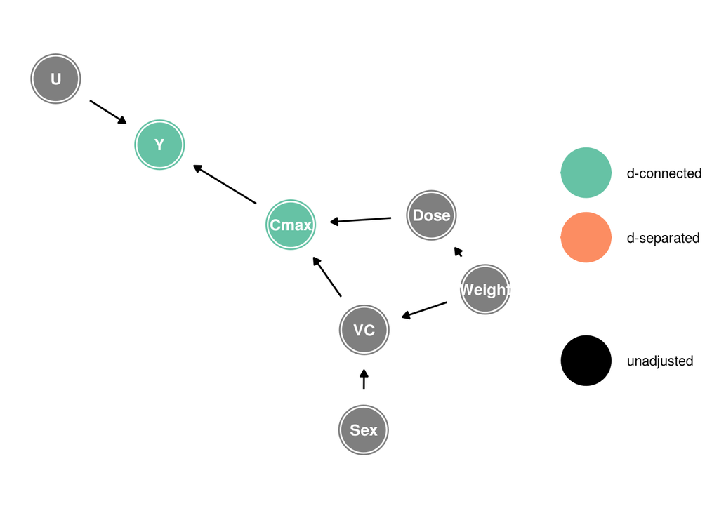

```r
library(ggdag)
pk_dag <- dagify( Y ~ Cmax + U, Cmax ~ Dose + VC, VC ~ Sex + Weight, Dose ~ Weight)
pk_dag %>% ggdag_dseparated(from = "Cmax", to = "Y") + theme_dag_blank()
```

The model published (Bajaj et al. 2017):
$$VC_{i} = VC_{ref} * \left (\frac{BW_i}{BW_{ref}}\right )^{VC_{BW}} \cdot \left (e^{VC_{SEX}}\right )^{SEX} \\
C_{max} = \frac{Dose}{VC_i}$$

## Generate a dataset

### Load libraries

```r
library(tidyverse)
library(kernlab)
library(pROC)
library(caret)
```

Generating data from R is not difficult. Indeed R may be the best suited language to generate data using the many probability distribution available in **stats** **base** package, and other packages.

### Simulation of a categorical outcome

Simulate weight variable.

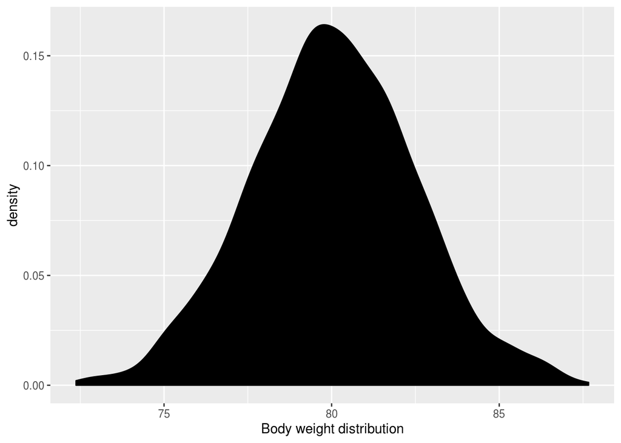

```r
N <- 2000
bw <-  rnorm(N, 0, 2.5) + 80
tibble::enframe(bw) %>%
  ggplot(aes(x = bw)) +
  geom_density(fill = "black") +
  coord_cartesian() +
  xlab("Body weight distribution")
```

```r
simdat <- tibble(
  id = paste("id", 1:N, sep = "_"),
  bw = rnorm(N, 0, 2.5) + 80,
  sex = rbinom(N, 1, .5) %>% as.factor
)
```

Now let us assume further that dose is adjusted using a PK/PD model to obtain a peak value that has not generated toxicity in Clinical trials, (our causal model):

```r
pkpop_vc <- function(bw, sex) {
  vcref <- 3.6
  bwref <- 80
  vcbw <- .597
  vcsex <- .152
  vc <- vcref * (bw / bwref)^(vcbw) * exp(vcsex)^I(sex == "1")
  vc %>% as.double()
}

simdat <- simdat %>%
  mutate(vc = pkpop_vc(bw, sex),
         dose = bw * 10^-3,
         cmax = (dose / vc) ) ## cmax in ng/mL
```

Finally we simulate the occurrence of the adverse event using a Bernoulli trial.

```r
## helper scale returns double
scale_this <- function(x){
  (x - mean(x, na.rm=TRUE)) / sd(x, na.rm=TRUE)
}
## helper transforms linear predictor to logistic scale
pr_bernouilli <- function(cmax) {
  beta1 <- 2
  eta <- scale_this(cmax) * beta1 ## normalise to obtain reasonable range of probabilities.
  pr <- 1 / (1 + exp(eta))
  rbinom(N, 1, pr)
}

simdat <- simdat %>%
  mutate(events = pr_bernouilli(cmax))

simdat %>% group_by(events) %>% count()
```

```
## # A tibble: 2 x 2
## # Groups:   events [2]
##   events     n
##    <int> <int>
## 1      0  1007
## 2      1   993
```

Take a step-back and see what would be a common available dataset. Prepare the dataset:

```r
fitdat <- simdat %>%
  mutate(Class = if_else(events == 1, "Fail", "Response")) %>%
  select(bw, sex, dose, Class)
```

### Fit the model

Now the dataset is given to us and let’s assume a PK modeller and a Machine Learning analyst working (together?) in this dataset. While the PK modeller has a clear understanding of the problem the Machine Learning scientist opts for using a fancy Machine Learning approach.

## Prepare the dataset in the caret package

First, we split the data into two groups: a training set and a test set. To do this, the createDataPartition function is used:

```r
inTrain <- createDataPartition(
  y = fitdat$Class,
  ## the outcome data
  p = .7,
  ## percentage of data in training set
  list = FALSE
)

## createDataPartition does a stratified random split of the data.
training <- fitdat[ inTrain, ]
testing <- fitdat[-inTrain, ]

nrow(training)
```

```
## [1] 1401
```

```r
nrow(testing)
```

```
## [1] 599
```

## Example

To fit a model in caret use the train function. For example a partial least squared discriminant analysis (PLSDA) model.

```r
plsFit <- train(
  Class ~ .,
  data = training,
  method = "pls",
  ## Center and scale the predictors for the training
  ## set and all future samples.
  preProc = c("center", "scale")
)
plsFit
```

```
## Partial Least Squares
##
## 1401 samples
##    3 predictor
##    2 classes: 'Fail', 'Response'
##
## Pre-processing: centered (3), scaled (3)
## Resampling: Bootstrapped (25 reps)
## Summary of sample sizes: 1401, 1401, 1401, 1401, 1401, 1401, ...
## Resampling results across tuning parameters:
##
##   ncomp  Accuracy   Kappa
##   1      0.8585391  0.7168687
##   2      0.8584620  0.7167136
##
## Accuracy was used to select the optimal model using  the largest value.
## The final value used for the model was ncomp = 1.
```

## The caret philosophy

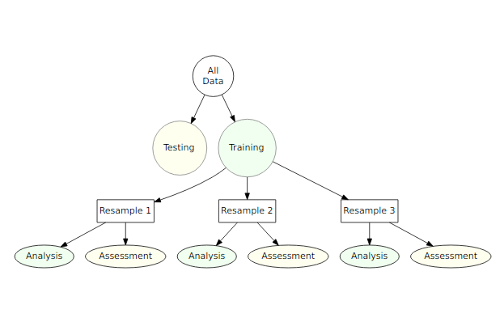

Set conditions for training model and cross-validation:

```r
number <- 5
repeats <- 2
control <- trainControl(method = "repeatedcv",
                        number = number ,
                        repeats = repeats,
                        classProbs = TRUE,
                        savePredictions = "final",
                        index = createResample(training$Class, repeats*number),
                        summaryFunction = multiClassSummary,
                        allowParallel = TRUE)
```

## The Data driven approach

The ML modeller uses a Support Vector Machine with an advanced Kernel, the radial basis function kernel.

```r
svmFit <-  ksvm(Class ~ . ,
            data = training %>%
              mutate_if(is_double, scale_this),
            kernel = "rbfdot",
            C = 10,
            epsilon = 0.1,
            prob.model = TRUE,
            cross = 10)
svmFit
```

```
## Support Vector Machine object of class "ksvm"
##
## SV type: C-svc  (classification)
##  parameter : cost C = 10
##
## Gaussian Radial Basis kernel function.
##  Hyperparameter : sigma =  2.00334252866598
##
## Number of Support Vectors : 727
##
## Objective Function Value : -3828.825
## Training error : 0.136331
## Cross validation error : 0.137771
## Probability model included.
```

## The PK modeller approach

The PK modeller opts for a logistic model using PK modelling.

```r
pk_training <- training %>%
  mutate(vc = pkpop_vc(bw, sex),
         cmax = (dose / vc) )

# Train Logistic Model:
logistic <- train(factor(Class) ~ cmax,
                  data = pk_training,
                  method = "glm",
                  preProcess = c("center", "scale"),
                  trControl = control)
coef(logistic$finalModel)
```

```
## (Intercept)        cmax
##  0.04175485  1.89165238
```

## Making predictions

Finally we must compare how both models performs.

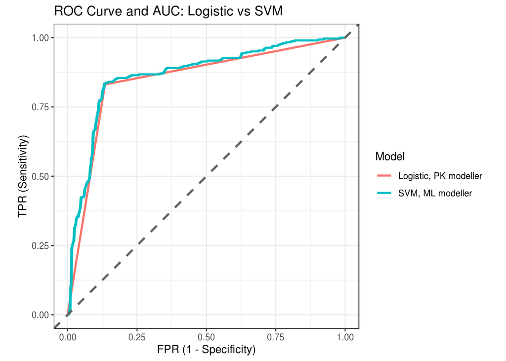

```r
## helper predicts probabilites
predict_prob <- function(model_selected, testdata) {
  predict(model_selected,
          testdata,
          type = "prob") %>%
    as.data.frame() %>%
    pull(Fail) %>%
    return()
}

## Calulate predicted probabilities
pred_logistic <- predict_prob(logistic, testing %>%
                                mutate(vc = pkpop_vc(bw, sex),
                                       cmax = (dose / vc) ) %>%
                                mutate_at("cmax", scale_this))
pred_svm <- predict_prob(svmFit, testing %>%
            mutate_if(is_double, scale_this) )

# Function calculates AUC:
test_auc <- function(prob) {
  roc(testing$Class, prob)
}

# Calculate AUC
auc_logistic <- test_auc(pred_logistic)
auc_svm <- test_auc(pred_svm)

# Create a data frame for comparing:
df_auc <- bind_rows(tibble(TPR = auc_logistic$sensitivities,
                               FPR = 1 - auc_logistic$specificities,
                               Model = "Logistic, PK modeller"),
                    tibble(TPR = auc_svm$sensitivities,
                               FPR = 1 - auc_svm$specificities,
                               Model = "SVM, ML modeller"))

# Plot ROC curves:
df_auc %>%
  ggplot(aes(FPR, TPR, color = Model)) +
  geom_line(size = 1) +
  theme_bw() +
  coord_equal() +
  geom_abline(intercept = 0, slope = 1, color = "gray37", size = 1, linetype = "dashed") +
  labs(x = "FPR (1 - Specificity)",
       y = "TPR (Sensitivity)",
       title = "ROC Curve and AUC: Logistic vs SVM")
```

```r
lapply(list(auc_logistic, auc_svm), function(x) {x[["auc"]]})
```

```
## [[1]]
## Area under the curve: 0.8482
##
## [[2]]
## Area under the curve: 0.8668
```

Or a more detailed report based on the test data: The PK modeller:

```r
confusionMatrix(predict(logistic, testing %>%
                      mutate(vc = pkpop_vc(bw, sex),
                                 cmax = (dose / vc) ) %>%
                                mutate_at("cmax", scale_this) ), testing$Class, positive = "Response")
```

```
## Confusion Matrix and Statistics
##
##           Reference
## Prediction Fail Response
##   Fail      257       51
##   Response   40      251
##
##                Accuracy : 0.8481
##                  95% CI : (0.8168, 0.8759)
##     No Information Rate : 0.5042
##     P-Value [Acc > NIR] : <2e-16
##
##                   Kappa : 0.6962
##  Mcnemar's Test P-Value : 0.2945
##
##             Sensitivity : 0.8311
##             Specificity : 0.8653
##          Pos Pred Value : 0.8625
##          Neg Pred Value : 0.8344
##              Prevalence : 0.5042
##          Detection Rate : 0.4190
##    Detection Prevalence : 0.4858
##       Balanced Accuracy : 0.8482
##
##        'Positive' Class : Response
##
```

```r
confusionMatrix(predict(svmFit, testing %>%
              mutate_if(is_double, scale_this) ), testing$Class, positive = "Response")
```

```
## Confusion Matrix and Statistics
##
##           Reference
## Prediction Fail Response
##   Fail      258       51
##   Response   39      251
##
##                Accuracy : 0.8497
##                  95% CI : (0.8186, 0.8774)
##     No Information Rate : 0.5042
##     P-Value [Acc > NIR] : <2e-16
##
##                   Kappa : 0.6996
##  Mcnemar's Test P-Value : 0.2463
##
##             Sensitivity : 0.8311
##             Specificity : 0.8687
##          Pos Pred Value : 0.8655
##          Neg Pred Value : 0.8350
##              Prevalence : 0.5042
##          Detection Rate : 0.4190
##    Detection Prevalence : 0.4841
##       Balanced Accuracy : 0.8499
##
##        'Positive' Class : Response
##
```

## But how do SVM work?

SVM construct an optimal separating hyperplane between two classes. Let’s visualise this with a simulation, here is the sample data:

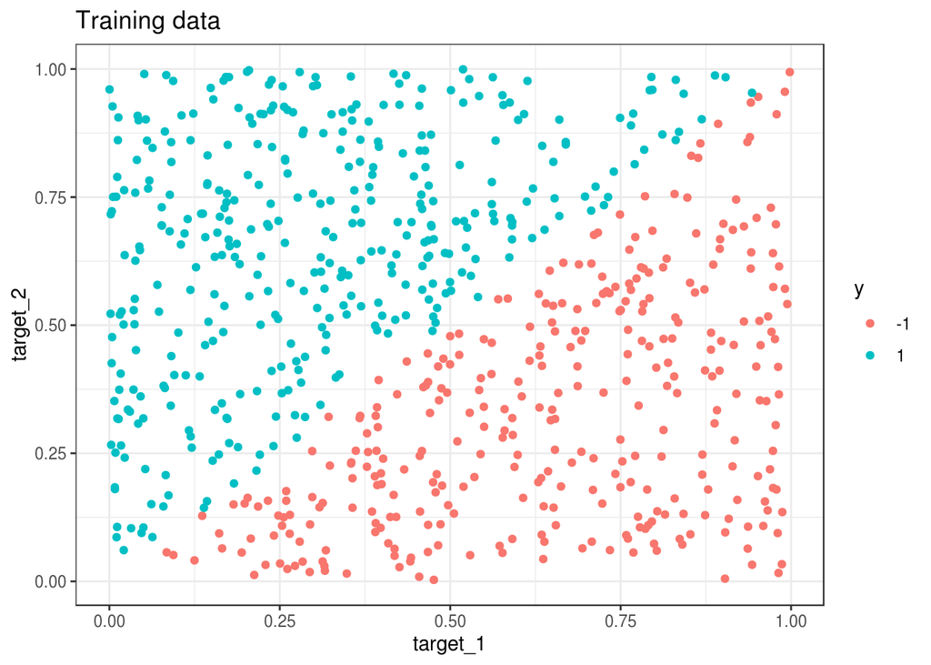

```r
N <- 1000
# Training
simdat <- tibble(
  target_1 = runif(N),
  target_2 = runif(N)
)
simdat <- simdat %>%
  mutate(y = if_else( target_2 > target_1, 1, -1) )
inTrain <- createDataPartition(
  y = simdat$y,
  ## the outcome data
  p = .7,
  ## percentage of data in training set
  list = FALSE
)
## createDataPartition does a stratified random split of the data.
training <- simdat[ inTrain, ]
testing <- simdat[-inTrain, ]
p1 <- training %>%
  mutate_at("y", as.factor) %>%
  ggplot(aes(x = target_1, y = target_2, colour = y)) +
  geom_point() + theme_bw()

p1 + ggtitle("Training data")
```

The SVs are plotted here:

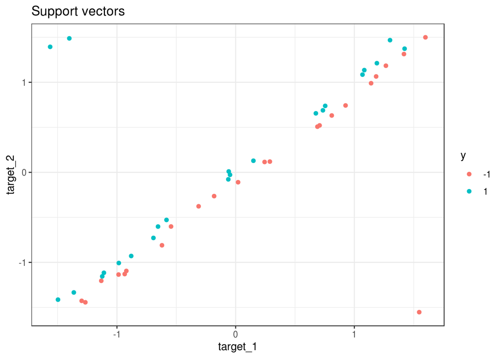

```r
# Vanilldadot gives a linear SVM
fit1 <- ksvm(factor(y) ~ .,
             data = training,
             kernel = "rbfdot",
             C = 10,
             epsilon = 0.1,
             prob.model = TRUE,
             cross = 10)

### Plot location of support vectors
SV1 <- training[alphaindex(fit1)[[1]],]

SV1 %>%
  mutate_at("y", as.factor) %>%
  mutate_if(is_double, scale_this) %>%
  ggplot(aes(x = target_1, y = target_2, colour = y)) +
  geom_point()  + theme_bw()  + ggtitle("Support vectors")
```

We can also extract the parameters of the decision line (i.e. its normal vector), and manually plot decision line and data:

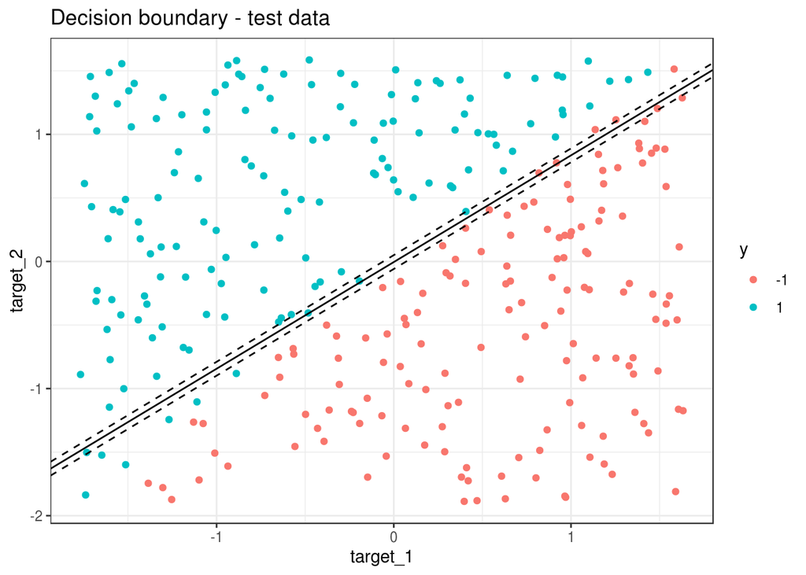

```r
w <- colSums(fit1@xmatrix[[1]] * fit1@coef[[1]])
b <- b(fit1)

p2 <- testing %>%
  mutate_at("y", as.factor) %>%
  mutate_if(is_double, scale_this) %>%
  ggplot(aes(x = target_1, y = target_2, colour = y)) +
  geom_point() + theme_bw() +
  geom_abline(intercept = b/w[1], slope = -w[2]/w[1]) +
  geom_abline(intercept = (b+1)/w[1], slope = -w[2]/w[1], linetype = 2) +
  geom_abline(intercept = (b-1)/w[1], slope = -w[2]/w[1], linetype = 2)

p2 + ggtitle("Decision boundary - test data")
```

## Genetic data and the high-dimensional nightmare

Let us assume that we have received some genetic data from a sample of patients. Maybe we can explain some unobserved factors from our model. But how can we add these predictors? Let us first simulate the scenario:

```r
N <- 100
n_gene <- 150
genesim <- matrix(rbinom(N*n_gene, 1, .7) , ncol = n_gene)
colnames(genesim) <- paste("gene_", 1:n_gene, sep = "_")
simdat <- tibble(
  id = paste("id", 1:N, sep = "_"),
  bw = rnorm(N, 0, 2.5) + 80,
  sex = rbinom(N, 1, .5) %>% as.factor
)
simdat <- bind_cols(simdat, genesim %>% as.data.frame())
simdat[1:6, 1:6]
```

```
## # A tibble: 6 x 6
##   id       bw sex   gene__1 gene__2 gene__3
##   <chr> <dbl> <fct>   <int>   <int>   <int>
## 1 id_1   80.8 0           1       1       1
## 2 id_2   80.3 1           1       1       1
## 3 id_3   77.1 1           1       0       1
## 4 id_4   80.0 1           1       1       1
## 5 id_5   81.7 1           0       0       1
## 6 id_6   79.0 0           1       0       1
```

As before we calculate the Cmax, and the probability of having an event.

```r
## tweaked function to sample genes that are impacting to the outcome
pr_bernouilli_gene <- function(dat) {
  beta1 <- 2
  gene_marker <- paste("gene_", sample(1:n_gene, 6), sep = "_")
  beta_gene <- c(0.9, -0.2, 0.5, -2.2, 0.7,  1.5)

  eta <- scale_this(dat$cmax) * beta1
  eta <- eta + (  as.matrix( dat %>% select(gene_marker))  %*% beta_gene  ) ## use R matrix multiplication
  pr <- 1 / (1 + exp(eta))
  rbinom(N, 1, pr)
}
simdat <- simdat %>%
  mutate(vc = pkpop_vc(bw, sex),
         dose = bw * 10^-3,
         cmax = (dose / vc) ) ## cmax in ng/mL
simdat <- simdat %>%
  mutate(events = pr_bernouilli_gene(.))
simdat %>% group_by(events) %>% count()
```

```
## # A tibble: 2 x 2
## # Groups:   events [2]
##   events     n
##    <int> <int>
## 1      0    58
## 2      1    42
```

We prepare to fit a model with caret:

```r
fitdat_gene <- simdat %>%
  mutate(Class = if_else(events == 1, "Fail", "Response")) %>%
  select(-id, -vc, -cmax, -events)

inTrain <- createDataPartition(
  y = fitdat_gene$Class,
  ## the outcome data
  p = .7,
  ## percentage of data in training set
  list = FALSE
)

## createDataPartition does a stratified random split of the data.
training_gene <- fitdat_gene[ inTrain, ]
testing_gene <- fitdat_gene[-inTrain, ]

nrow(training_gene)
```

```
## [1] 71
```

```r
nrow(testing_gene)
```

```
## [1] 29
```

```r
pk_training_gene <- training_gene %>%
  mutate(vc = pkpop_vc(bw, sex),
         cmax = (dose / vc) )
control <- trainControl(method = "repeatedcv",
                        number = number ,
                        repeats = repeats,
                        classProbs = TRUE,
                        savePredictions = "final",
                        index = createResample(pk_training_gene$Class, repeats*number),
                        summaryFunction = multiClassSummary,
                        allowParallel = TRUE)
logistic <- train(factor(Class) ~ . - dose - sex - bw - vc,
                  data = pk_training_gene %>%
                    mutate_at("cmax", scale_this),
                  method = "glm",
                  trControl = control)
```

[output not shown]

```r
warnings()
```

So we call our Machine Learning colleague and he says that he remembers that we can use penalised regression in this case:

```r
cctrl1 <- trainControl(method="cv",
                       number=3,
                       returnResamp="all",
                       classProbs=TRUE,
                       summaryFunction=twoClassSummary)

logisticnet <- train(factor(Class) ~ . - dose - sex - bw - vc,
                    data = pk_training_gene %>%
                      mutate_at("cmax", scale_this),
                    method = "glmnet",
                    metric = "ROC",
                    trControl = cctrl1,
                    tuneGrid = expand.grid(alpha = 1,lambda = seq(0.001,0.1,by = 0.001)))
```

So how does it work?

```r
coef(logisticnet$finalModel, logisticnet$bestTune$lambda)
```

```
## 152 x 1 sparse Matrix of class "dgCMatrix"
##                        1
## (Intercept)  6.682763460
## gene__1      .
## gene__2      .
## gene__3      .
## gene__4      .
## gene__5      .
## gene__6      0.624712999
## gene__7     -0.684948716
## gene__8      .
## gene__9      .
## gene__10     0.652370857
## gene__11     .
## gene__12     .
## gene__13     .
## gene__14     0.161279161
## gene__15     .
## gene__16     .
## gene__17    -0.095807577
## gene__18     .
## gene__19    -0.674931422
## gene__20    -0.714375959
## gene__21    -1.617810587
## gene__22     0.001296641
## gene__23     .
## gene__24     0.526689763
## gene__25    -1.943378144
## gene__26     .
## gene__27    -0.797728520
## gene__28     .
## gene__29     .
## gene__30     .
## gene__31     .
## gene__32    -0.531142897
## gene__33     .
## gene__34    -0.299142452
## gene__35     .
## gene__36    -0.293532470
## gene__37    -1.309865131
```

[output cut: 99 more lines]

```
## gene__137    .
## gene__138    .
## gene__139    .
## gene__140    .
## gene__141    .
## gene__142    .
## gene__143    .
## gene__144    .
## gene__145    .
## gene__146    .
## gene__147    1.294542010
## gene__148    .
## gene__149    .
## gene__150   -1.828225838
## cmax         3.032991484
```

There is a built in plot method in the glmnet package:

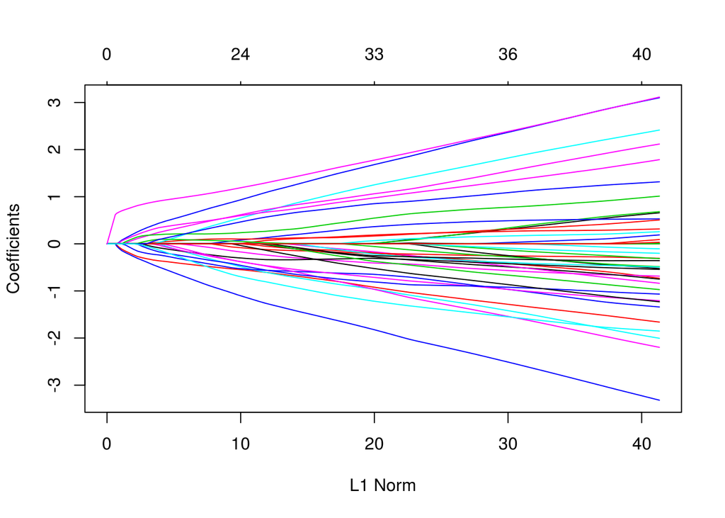

```r
lasso_mod <- logisticnet$finalModel
glmnet::plot.glmnet(lasso_mod)
```

Or we can design a function to create a ggplot, see in [StackOverflow](https://stackoverflow.com/questions/48978179/r-plotting-lasso-beta-coefficients):

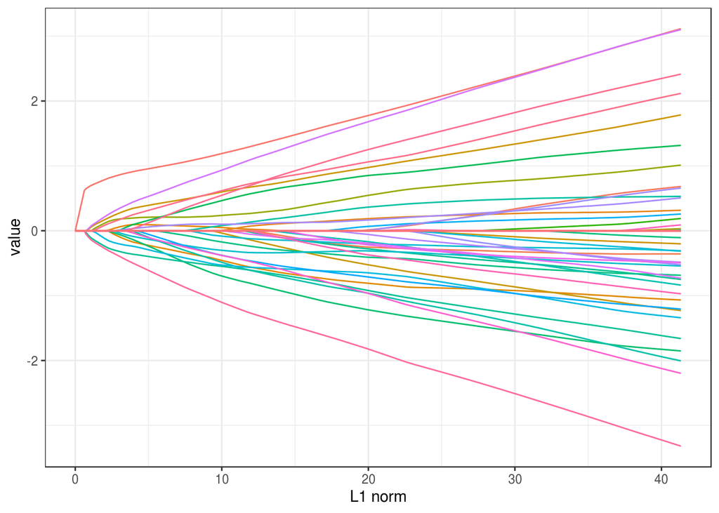

```r
plot_lasso_norm <- function(lasso_mod){
  # best coefficient
  beta=coef(lasso_mod)
  tmp <- as.data.frame(as.matrix(beta))
  tmp$coef <- row.names(tmp)
  tmp <- reshape::melt(tmp, id = "coef")
  tmp$variable <- as.numeric(gsub("s", "", tmp$variable))
  tmp$lambda <- lasso_mod$lambda[tmp$variable+1] # extract the lambda values
  tmp$norm <- apply(abs(beta[-1,]), 2, sum)[tmp$variable+1] # compute L1 norm

  ggplot(tmp[tmp$coef != "(Intercept)",], aes(norm, value, colour = coef)) +
    geom_line() +
    xlab("L1 norm") +
    theme_bw() +
    theme(legend.position = "none")
}
plot_lasso_norm(lasso_mod)
```

# Exercise

Use your knowledge in modelling and simulation in R to simulate the model discussed above (Bajaj et al. 2017), where the outcome Y is a continuous variable (instead of Bernoulli). This could be for example the SLD or another continuous outcome affected by Cmax. Train the model using the caret package. Also, look in caret for a Machine Learning method for regression and apply it. Compare the predictions of both models using a performance measure for regression. Optional: the package **yardstick** could be useful to do so.

# References

Bajaj, G, X Wang, S Agrawal, M Gupta, A Roy, and Y Feng. 2017. “Model-Based Population Pharmacokinetic Analysis of Nivolumab in Patients with Solid Tumors.” *CPT: Pharmacometrics & Systems Pharmacology* 6 (1). Wiley Online Library: 58–66.